# Um passeio pela história do cinema com o IMDB e o R

Vitor H. F. Vieira

2022-11-28

# O que é o IMDB?

O IMDB é uma base de dados on-line que reúne informações a respeito das grandes indústrias de entretenimento do mundo, em particular a cinematográfica, que será objeto de estudo neste trabalho. Fundado em 1990, mantém-se até hoje como fonte confiável para obtenção de informações técnicas a respeito da Sétima Arte. Vamos desbravá-lo?

Para tal, carreguemos a base de dados mais ampla do IMDB chamada `imdb_completa`, formada por mais de oitenta e cinco mil linhas e vinte e uma colunas, que traz informações gerais em relação a milhares de filmes, contemplando toda a história do cinema, desde o final do século XIX até a década 2020. Além disso, carreguemos também o pacote `tidyverse`:

```r
library (tidyverse)
imdb_completa <- basesCursoR::pegar_base("imdb_completa")

dplyr::glimpse(imdb_completa)
```

```
## Rows: 85,855
## Columns: 21
## $ id_filme             <chr> "tt0000009", "tt0000574", "tt0001892", "tt0002101…
## $ titulo               <chr> "Miss Jerry", "The Story of the Kelly Gang", "Den…
## $ titulo_original      <chr> "Miss Jerry", "The Story of the Kelly Gang", "Den…
## $ ano                  <dbl> 1894, 1906, 1911, 1912, 1911, 1912, 1919, 1913, 1…
## $ data_lancamento      <chr> "1894-10-09", "1906-12-26", "1911-08-19", "1912-1…
## $ genero               <chr> "Romance", "Biography, Crime, Drama", "Drama", "D…
## $ duracao              <dbl> 45, 70, 53, 100, 68, 60, 85, 120, 120, 55, 121, 5…
## $ pais                 <chr> "USA", "Australia", "Germany, Denmark", "USA", "I…
## $ idioma               <chr> "None", "None", NA, "English", "Italian", "Englis…
## $ orcamento            <chr> NA, "$ 2250", NA, "$ 45000", NA, NA, NA, "ITL 450…
## $ receita              <chr> NA, NA, NA, NA, NA, NA, NA, NA, NA, NA, NA, NA, N…
## $ receita_eua          <chr> NA, NA, NA, NA, NA, NA, NA, NA, NA, NA, NA, NA, N…
## $ nota_imdb            <dbl> 5.9, 6.1, 5.8, 5.2, 7.0, 5.7, 6.8, 6.2, 6.7, 5.5,…
## $ num_avaliacoes       <dbl> 154, 589, 188, 446, 2237, 484, 753, 273, 198, 225…
## $ direcao              <chr> "Alexander Black", "Charles Tait", "Urban Gad", "…
## $ roteiro              <chr> "Alexander Black", "Charles Tait", "Urban Gad, Ge…
## $ producao             <chr> "Alexander Black Photoplays", "J. and N. Tait", "…
## $ elenco               <chr> "Blanche Bayliss, William Courtenay, Chauncey Dep…
## $ descricao            <chr> "The adventures of a female reporter in the 1890s…
## $ num_criticas_publico <dbl> 1, 7, 5, 25, 31, 13, 12, 7, 4, 8, 9, 9, 16, 8, NA…
## $ num_criticas_critica <dbl> 2, 7, 2, 3, 14, 5, 9, 5, 1, 1, 9, 28, 7, 23, 4, 2…
```

Neste momento, tentemos explorar a base de dados a partir de algumas perguntas. Qual é o mês do ano com mais estreias cinematográficas, segundo o IMDB? E o dia do ano?

Para responder a essas perguntas, escolhemos a variável de interesse `data_lançamento`, transformando-a em data, e excluímos os valores nulos desta coluna, para que possamos dividi-la em três.

```r
imdb_completa2 <- imdb_completa |>
  select(titulo, data_lancamento) |>
  mutate(data_lancamento = as.Date(data_lancamento)) |>
  drop_na (data_lancamento)


# Divide-se em três a coluna relativa à data.


imdb_data <- imdb_completa2 |>
  mutate (ano = lubridate::year(data_lancamento),
          mes = lubridate::month(data_lancamento),
          dia = lubridate::day(data_lancamento))
```

É possível responder às perguntas iniciais de duas formas: uma mais simples e outra mais detalhada. Vamos a elas?

A partir de uma função sobre a qual calculamos a moda, o termo mais repetido dentro de um vetor, temos:

```r
# A função abaixo busca o termo mais repetido dentro uma coluna.

mais_repetido <- function(x) {
  uniqx <- unique(x)
  uniqx[which.max(tabulate(match(x, uniqx)))]
}

mais_repetido(imdb_data$mes)
```

```
## [1] 10
```

Assim, o mês do ano com o maior número de filmes lançados dentre todos os filmes cuja data de estreia é conhecida é o décimo mês do ano, o popular outubro!

Mas, quantos filmes, dentre todos os 81292 cuja data de lançamento é conhecida, foram lançados no mês de outubro, segundo o IMDB?

Em primeiro lugar, cria-se uma função chamada `filmes_lancados_total`, cujo ofício é reagrupar os dados em questão a partir de um vetor, criando uma nova variável a partir da contagem de observações. Como o novo agrupamento repete a informação relevante para cada filme de forma individual, usemos o `distinct` para descartar o material repetido e ordenemos a nova coluna de maneira decrescente. Por fim, com o `lubridate` iremos transformar o mês em uma classe de `fatores`, de modo que estes sejam representados pelos seus respectivos nomes em português, além de escolhermos as variáveis de interesse com o `select`.

```r
filmes_lancados_total<- function (data, by, ...) {
  data %>%
    group_by({{by}}) |>
    mutate(filmes=n()) |>
    ungroup()
}

imdb_meses <- imdb_data |>
  filmes_lancados_total (mes) |>
  distinct(mes, filmes) |>
  arrange(desc(filmes)) |>
  mutate (mes = lubridate::month(mes, label = TRUE)) |>
  select(mes, filmes)
```

Tabela 1: Os seis meses do ano com mais estreias cinematográficas

| mes | filmes |
| --- | --- |
| out | 8734 |
| set | 7924 |
| mar | 7435 |
| nov | 7094 |
| abr | 7078 |
| dez | 6618 |

Portanto, confirmamos que o mês em que mais houve estreias cinematográficas, segundo o IMDB, foi outubro, seguido pelo meses de setembro, março e novembro, apontando uma tendência de lançamentos na segunda metade do ano, como observamos anteriormente. Agora vamos além: qual é o dia, dentre todos aqueles dentro de um ano, em que mais houve concentração de estreias no cinema?

Primeiramente, reaproveitemos do exercício anterior a tibble `imdb_data`, que contempla todos aqueles filmes cuja data está em sua forma completa, dividida por dia, mês e ano. Para tal, vamos reunir os meses aos dias, de forma que haja uma nova coluna chamada `mes_dia`, pela qual reagruparemos os dados com a função `filmes_lançados_total`, utilizada anteriormente. Repetindo os mesmos processos anteriores, transformamos as colunas relativas a dia e mês em classe númerica para que esta última possa ser referida como um fator de meses com o `lubridate`. Assim, temos:

```r
imdb_data2 <- imdb_data |>
  unite("mes_dia", mes:dia, sep = "-") |>
  filmes_lancados_total(mes_dia) |>
  distinct(mes_dia, filmes ) |>
  separate(mes_dia, c("mes", "dia")) |>
  mutate(mes = as.double(mes),
         dia = as.double(dia),
         filmes_estreia_total = filmes) |>
  select(mes, dia, filmes) |>
  arrange(desc(filmes))

# transformando a coluna relativa a mês em data.
imdb_mes_dia_tibble <- imdb_data2 |>
  mutate(mes = lubridate::month(mes, label = TRUE)
         )
```

Tabela 2: Os 10 dias do ano com mais estreias cinematográficas (1894-2020)

| mes | dia | filmes |
| --- | --- | --- |
| out | 1 | 747 |
| mar | 1 | 657 |
| set | 1 | 638 |
| dez | 1 | 634 |
| abr | 1 | 623 |
| nov | 1 | 619 |
| mai | 1 | 598 |
| fev | 1 | 598 |
| jan | 1 | 590 |
| jun | 1 | 575 |

Portanto, de todas as datas dentro um ano o 1º de outubro é aquela que comporta mais estreias cinematográficas. Por outro lado, segundo a tabela acima, as dez maiores datas de estreia são aquelas relativas ao primeiro dia de um mês. Não é um comportamento estranho?

É possível que, dentro do IMDB, o primeiro dia de um mês seja padrão para aquelas estreias cujo o dia é desconhecido, ainda que se conheça o mês de lançamento. Assim, filtraremos apenas o dia de estreia, de modo que seja maior do que 1, contabilizando somente os demais dias.

```r
imdb_mes_dia_tibble_mqu <- imdb_mes_dia_tibble |>
  filter (dia > 1)
```

Tabela 3: Os 10 dias do ano com mais estreias cinematográficas (com exceção do dia 1º de cada mês)

| mes | dia | filmes |
| --- | --- | --- |
| out | 31 | 365 |
| dez | 25 | 320 |
| out | 18 | 316 |
| fev | 14 | 311 |
| out | 10 | 310 |
| out | 25 | 302 |
| out | 26 | 294 |
| out | 28 | 290 |
| dez | 20 | 287 |
| set | 13 | 285 |

Agora sim! Das cinco maiores datas de estreia dentro de um ano, excluindo o primeiro dia de cada mês, há dois importantes dias comemorativos, dentre os quais o dia de Natal e o dia de São Valentim, quando se comemora o Dia dos Namorados em muitas partes do mundo. Por sua vez, o primeiro lugar fica por conta do dia das Bruxas, o popular Halloween, também comemorado mundialmente no dia 31 de outubro.

## E os países?

Quais são os países que mais produzem filmes no mundo segundo o IMDB?

Mais uma vez, selecionaremos as colunas de interesse, separamos a coluna de países e retiramos os valores nulos, de forma que cada país conte individualmente para cada filme. Voltamos a usar a função que agrupa o número total de filmes a partir de uma coluna e usamos `distinct` para reorganizar a tibble.

```r
imdb_paises <- imdb_completa |>
  select(titulo_original, ano, pais) |>
  separate_rows(pais, sep = "\\, ") |>
  drop_na(pais) |>
  filmes_lancados_total(pais) |>
  distinct(pais, filmes) |>
  arrange(desc(filmes)) |>
  slice(1:5)
```

Tabela 4: Os países que mais produziram filmes no mundo (1894-2020)

| pais | filmes |
| --- | --- |
| USA | 34325 |
| France | 8311 |
| UK | 7490 |
| India | 6373 |
| Italy | 5056 |

Sem maiores surpresas, o primeiro lugar é dos Estados Unidos, onde se localiza a longeva indústria de Hollywood. Em seguida, tem-se a França, local onde o cinema floresceu como invenção pelas mãos dos irmãos Lumière. O intruso não-ocidental da lista é a Índia, cuja fama de sua Bollywood é mundial. Assim como Reino Unido e França, o que une os países que mais produzem filmes no mundo , portanto, é o fato de que suas indústrias são muito bem assentadas para o consumo interno, de modo que há o hábito de demanda relevante por cinema nesses países.

## E as moedas?

Muitos países trocaram de moeda nas últimas décadas, principalmente após a adoção do Euro pela União Europeia. Assim, tem-se em mãos a pertinente pergunta: quantos padrões monetários aparecem na base de dados `imdb_completa` ?

Para tal, façamos a contagem de moedas individualmente para as colunas relativas ao orçamento e receita. Para começar, selecionamos as variáveis que nos interessa, excluindo os valores nulos. Com ajuda de uma expressão regular, extraíremos apenas os padrões monetários que iniciam cada coluna. Repetimos os passos usados anteriormente ao usar a função `filmes_lancados_total` e `distinct` para reorganizarmos aquilo que nos interessa. Por fim, iremos confirmar se há o mesmo número de fillmes em ambas as colunas de interesse.

```r
imdb_orcrec <- imdb_completa |>
  select(titulo_original, ano, orcamento, receita) |>
  drop_na (c("orcamento", "receita"))

regex = "[A-Z|\\$]+(?=\\s)"

# A-Z maicusculo, |, caractere monetário relativo ao dólar.


imdb_moedas <- imdb_orcrec |>
  mutate(moeda_orc = str_extract(orcamento, regex),
         moeda_rec = str_extract(receita, regex)) |>
  select(titulo_original, ano, moeda_orc, moeda_rec)


imdb_orcamento <- imdb_moedas |>
  filmes_lancados_total(moeda_orc) |>
  distinct(moeda_orc, filmes) |>
  arrange(desc(filmes))

imdb_receita <- imdb_moedas |>
  filmes_lancados_total(moeda_rec) |>
  distinct(moeda_rec, filmes)

#

n_filmes_orc <- imdb_orcamento |>
  mutate(filmes_em_orcamento = sum(filmes),
         filmes_em_receita = sum(filmes)) |>
  select(filmes_em_orcamento, filmes_em_receita) |>
  distinct(filmes_em_orcamento, filmes_em_receita)

n_filmes_orc$filmes_em_orcamento == n_filmes_orc$filmes_em_receita
```

```
## [1] TRUE
```

Isto posto, podemos dizer que os mesmos filmes que fazem parte de `imdb_orcamento` compõem também `imdb_receita`. Como visto abaixo, a única unidade monetária presente nas receitas do IMDB é relativa ao dólar, o que pode ser explicado pelo fato de um mesmo filme poder ser lançado em várias partes do mundo ao longo do tempo. Neste caso, a padronização monetária facilita a vida tanto de nós, analistas, quanto a daqueles que efetivamente colocam seu dinheiro em jogo nas maiores indústrias de cinema do mundo.

```r
imdb_receita
```

```
## # A tibble: 1 × 2
##   moeda_rec filmes
##   <chr>      <int>
## 1 $          12762
```

Agora vamos ao que interessa: na tabela abaixo, há uma relação com os padrões monetários mais abundantes no cinema, segundo o IMDB. De todas as 62 moedas presentes, as mais recorrentes são dólar, euro e rúpia, oriundas de Estados Unidos, União Europeia e Índia, respectivamente, locais que reconhecidamente contam com indústrias bem estabelecidas de cinema.

```r
tabela_orc <- imdb_orcamento |>
  slice (1:3)|>
  rename(moeda = moeda_orc) |>
  mutate(regiao = c("Estados Unidos", "União Europeia", "Índia")) |>
  select(moeda, regiao, filmes)
```

Tabela 5: Os padrões monetários mais recorrentes no IMDB

| moeda | regiao | filmes |
| --- | --- | --- |
| $ | Estados Unidos | 9025 |
| EUR | União Europeia | 1820 |
| INR | Índia | 335 |

## Gêneros e lucro

Por falar em padrões monetários, vamos explorar um pouco mais a nossa base de dados. Assim, considerando apenas valores em dólar, qual o gênero do IMDB que concentra maior lucro?

Primeiramente, repetiremos o passo inicial de outrora ao selecionar as colunas que nos interessam. A longa lista em `select` se justifica pelo fato de que voltaremos à `imdb_orcam_rec` futuramente. Assim, comecemos de fato descartando os valores nulos dentro das colunas de orçamento e receita. Em seguida, com ajuda de uma expressão regular, filtramos para que somente os filmes cujo orçamento estejam dolarizados apareçam.

Além disso, com a mão de outra expressão regular, descartamos o padrão monetário norte-americano, de forma que as colunas sejam preenchidas apenas por valores númericos. Dessa forma, estamos livres para criar uma nova variável chamada `lucro`.

Como temos valores monetários que se alteram ao longo do tempo, teremos de trazer os valores de lucro para o presente. Com ajuda do `priceR`, deflaciona-se a coluna relativa ao lucro a valores correntes em dólar americano de 2020 – cujo processo não será estendido neste relatório por conta da demora relativa ao processo e a aparente incompatibilidade do `priceR` com o chunk do RMD, preferindo-se carregar apenas o arquivo .rds com valores já deflacionados. O uso do pacote em ação pode ser visto no [Github](https://github.com/vitorhfv/Projects/blob/main/TCC%20-%20Curso%20R/R/03_tratamento_dolar.R). Em seguida, organizamos a tibble que responde a nossa pergunta ao separarmos a coluna de gênero, de modo que, tal qual anteriormente, tenhamos um filme para cada agrupamento de forma individual e uma nova coluna relativa ao lucro total de cada gênero.

```r
library(tidyverse)

regex_dolar = "^[\\$]"
regex_num = "\\(?[0-9,.]+"


imdb_orcam_rec <- imdb_completa |>
  select(titulo_original,
         ano,
         data_lancamento,
         nota_imdb,
         direcao,
         elenco,
         genero,
         orcamento,
         receita) |>
  drop_na(c("orcamento", "receita")) |>
  filter (str_detect(orcamento, regex_dolar)) |>
  mutate(orcamento = as.double(str_extract(orcamento, regex_num)),
         receita = as.double(str_extract(receita, regex_num)),
         lucro = receita - orcamento)

# A partir da linha 31 do arquivo "03_tratamento_dolar.R" o uso do priceR
# é exemplificado.

imdb_orcam_rec = readRDS("data/rds/imdb_orc_rec.rds")

genero_lucro_real <- imdb_orcam_rec |>
  separate_rows(genero, sep = "\\, ") |>
  group_by(genero) |>
  summarise(lucro_soma_genero = sum(lucro_real)) |>
  arrange(desc(lucro_soma_genero)) |>
  slice(1:5) |>
  mutate(genero = c("Aventura",
                    "Ação",
                    "Comédia",
                    "Drama",
                    "Animação"))
```

Com ajuda do `ggplot`, podemos fazer um gráfico que responda a pergunta. Para tal, temos o auxílio do pacote `forcats`, que transforma em fator cada gênero cinematográfico a partir do seu lucro total, de modo que tenhamos um gráfico em formato decrescente, do maior lucro por gênero até o menor, facilitando a leitura da informação.

```r
grafico_lucro_generos <- genero_lucro_real |>
  mutate(genero = forcats::fct_reorder(genero, lucro_soma_genero)) |>
  ggplot()+
  aes(x = lucro_soma_genero, y = genero) +
  geom_col ()+
  scale_x_continuous (labels = scales::dollar_format())+
  labs (x = "lucro total acumulado (em dólares americanos)",
        y = "gêneros",
        caption = "Fonte: IMDB")
```

Gráfico 1: Os gêneros mais lucrativos do cinema

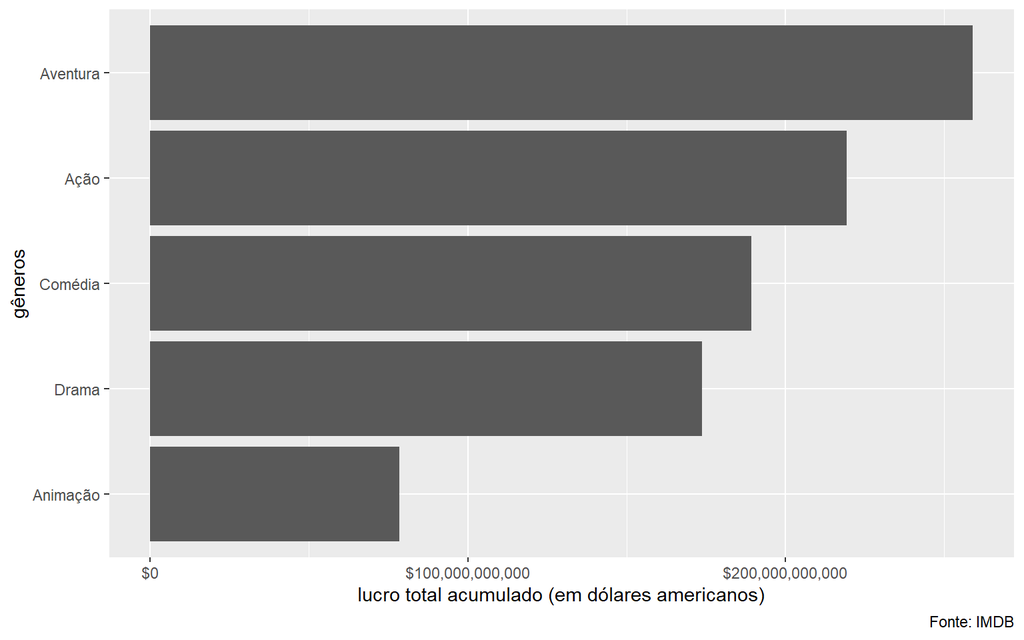

```r
grafico_lucro_generos + theme_gray()
```

Como observado no Gráfico 1, o gênero que mais acumulou lucro ao longo da história do cinema, segundo o IMDB, foi o de aventura, catapultado por grandes arrasa-quarteirões da história do cinema, como Os Caçadores da Arca Perdida (1981) e Guerra nas Estrelas (1977). Em seguida, tem-se ação, que engloba as célebres obras de super-herói da DC e Marvel, especialmente. Esses filmes são considerados um “gamechanger” dentro da indústria, por transformarem os espectadores em “torcedores” assíduos de suas histórias, de forma que é criado um vínculo entre uma franquia e aqueles que assistem. Se tal comportamento já levou Martin Scorsese a comparar as obras da Marvel a “parque de diversões”, tamanho ônus somente reforça o faturamento – e os lucros – da empresa. Por fim, há drama e comédia e animação, gêneros tradicionais e vistos como bom chamariz de público pelos grandes estúdios.

## E as notas por gênero?

Já temos o ranking de gêneros mais lucrativos do cinema. Porém, como saber qual o gênero mais aceito por aqueles que acompanham a Sétima Arte?

Para tal, reaproveitemos `imdb_orcam_rec`, tibble do exercício anterior, selecionando aquilo que nos interessa e separando a coluna referente aos gêneros, de modo que um mesmo filme possa ser contabilizado por diferentes categorias. A seguir, agrupamos o dataframe por gênero a partir da média de notas do IMDB, filtrando apenas gêneros com mais do que mill filmes contabilizados. Assim, teremos amostras bastante representativas apenas para os gêneros mais tradicionais do cinema. Por fim, arrendondamos os valores da coluna `media_imdb` para que haja somente dois números após a vírgula e ordenamos a tibble de forma decrescente a partir das médias da notas do IMDB. Quanto ao gráfico, por sua vez, voltemos a usar o `ggplot2`. Aliado ao pacote `forcats`, as barras aumentam conforme o ordenamento, deixando a média do IMDB visível apenas para fins didáticos.

```r
imdb_genero_nota <- imdb_orcam_rec |>
  select(titulo_original, ano, nota_imdb, genero) |>
  separate_rows(genero, sep = "\\, ") |>
  group_by(genero) |>
  summarise(media_imdb = mean(nota_imdb),
            filmes_db = n ()) |>
  filter (filmes_db > 1000) |>
  arrange(desc(media_imdb)) |>
  mutate(media_imdb = round(media_imdb, 2)) |>
  slice(1:5)
```

Gráfico 2: Os cinco gêneros mais bem avaliados do IMDB

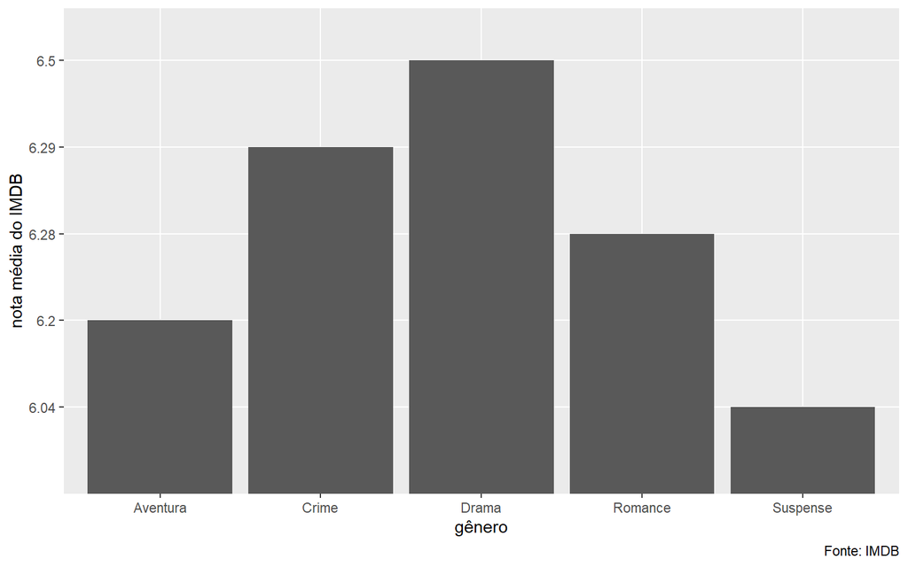

```r
imdb_genero_nota |>
  mutate(media_imdb = forcats::as_factor(media_imdb),
         genero = c("Drama", "Crime", "Romance", "Aventura", "Suspense")) |>
  ggplot()+
  aes(x = genero, y = media_imdb)+
  geom_col()+
  labs(x = "gênero",
       y = "nota média do IMDB",
       caption = "Fonte: IMDB")
```

Como visto no Gráfico 2, o gênero mais bem avaliado do IMDB, se contabilizarmos apenas gêneros com mais de mil filmes, é o milenar drama, oriundo do teatro grego em oposição à comédia. Tal categoria contempla diversos clássicos da história do cinema, incluindo o número um da raking IMDB 250, o norte-americano Um Sonho de Liberdade (1994). É também o gênero que mais contempla filmes dentre todos aqueles cujo orçamento e receita aparecem em dólar na plataforma. Completam o raking os gêneros relativos a crime, romance, aventura e suspense, respectivamente.

Agora podemos avançar mais um pouco e responder a uma nova pergunta: quais os filmes mais lucrativos da história, segundo o IMDB, com valores atualizados?

Para tal, carreguemos `imdb_receita_real.rds`, que conta com uma coluna com os valores de bilheteria em dólar atualizados ao longo do tempo a partir do `priceR`. As pastas relativas aos códigos podem ser acessadas a partir do [Github](https://github.com/vitorhfv/Projects/blob/main/TCC%20-%20Curso%20R/R/03_tratamento_dolar.R). Assim, selecionamos as colunas de interesse, organizando `lucro_real` de forma decrescente, selecionando apenas os dez primeiros e renomeando o nome de cada coluna, além de transformar a coluna relativa ao lucro em valores monetários. Assim, tem-se:

```r
# O passo a passo do uso do priceR para deflacionar o valor da receita está na
# linha 137 de "03_tratamento_dolar.R", que pode ser acessada a partir
# do link Github no parágrafo acima.

imdb_receita_real <- readRDS("data/rds/imdb_receita_real.rds")

imdb_receita_real_f <- imdb_receita_real |>
  arrange(desc(receita_real)) |>
  slice (1:10) |>
  mutate(receita_real = scales::dollar(receita_real)) |>
  rename(titulo = titulo_original, receita = receita_real)
```

Tabela 6: Os filmes com as maiores bilheterias da história, com valores em dólar atualizados (1920-2020)

| titulo | ano | receita |
| --- | --- | --- |
| Gone with the Wind | 1939 | $3,572,327,286 |
| Titanic | 1997 | $3,539,411,119 |
| Avatar | 2009 | $3,366,304,166 |
| Star Wars | 1977 | $3,312,707,117 |
| Avengers: Endgame | 2019 | $2,832,313,795 |
| The Exorcist | 1973 | $2,572,408,969 |
| Jaws | 1975 | $2,269,722,014 |
| Star Wars: Episode VII - The Force Awakens | 2015 | $2,258,401,194 |
| E.T. the Extra-Terrestrial | 1982 | $2,128,104,127 |
| Avengers: Infinity War | 2018 | $2,111,206,496 |

A maior bilheteria da história do cinema, a valores correntes em dólar de 2020, é do clássico norte-americano E O Vento Levou (1939), épico romance cuja história remonta às consequências da Guerra da Secessão nos Estados Unidos sob os olhares do casal vivido por Vivien Leigh e Clark Gable. Curiosamente, é o filme mais antigo dentre aqueles dez que compõem as maiores receitas. A seguir, há Titanic (1997), protagonizado por Leonardo DiCaprio e Kate Winslet e representante único da década de 1990 na lista. Completam o grupo acima de U$ 3 bilhões dois filmes de aventura, Avatar (2009) e Guerra nas Estrelas (1977).

## E o favorito?

Aliado ao carregamento de outras bases de dados do IMDB, podemos responder à perguntas a respeito de personalidades do cinema em específico, como atores ou diretores. Façamos, então, um exercício em relação ao cineasta que dirige filme favorito deste que vos escreve, A Felicidade Não se Compra (1946). Para tal, precisamos carregar dois outros arquivos, `imdb_pessoas` e `lucro_real.rds`, este último oriundo de uma atividade anterior, contando com a ajuda dos pacotes que compõem o `tidyverse`, além do `lubridate`. Uma observação importante a se fazer é que a data de estreia que a base de dados mais completa do IMDB nos mostra é referente ao lançamento na Itália, enquanto a coluna de ano é relativa à estreia em seu país de origem. Desse modo, tem-se:

```r
imdb_pessoas <- basesCursoR::pegar_base("imdb_pessoas")
lucro_real <- readRDS("data/rds/lucro_real.rds")

# Ano de estreia do filme favorito, filtrando a partir de ano e diretor.

afnsc_ano_orig <- imdb_completa |>
  select(titulo_original, ano, direcao) |>
  filter(direcao == "Frank Capra",
         ano == "1946")

# Filme favorito no ranking IMDB (para filmes com mais de 50 mil avaliações)

afnsc_imdb <- imdb_completa |>
  select(titulo_original, ano, nota_imdb, num_avaliacoes) |>
  filter(num_avaliacoes > 50000) |>
  arrange(desc(nota_imdb)) |>
  slice(1:25) |>
  rownames_to_column("ranking") |>
  tail() |>
  rename(titulo = titulo_original,
         nota = nota_imdb,
         avaliacoes = num_avaliacoes)

# Para calcular a diferença temporal ao nascimento/morte do diretor
# é preciso filtrar a partir de "imdb_pessoas"

capra_pessoa <- imdb_pessoas |>
  filter (nome == "Frank Capra") |>
  mutate(local_falecimento = "La Quinta, California, USA")

# diferença morte e nascimento

nascimento = lubridate::as_date(capra_pessoa$data_nascimento)
falecimento = lubridate::as_date(capra_pessoa$data_falecimento)
falecimento1 = as.character(falecimento)
intervalo <- lubridate::interval(start = nascimento, end = falecimento)
resultado <- lubridate::as.period(intervalo, unit = "year")
resultado1 = as.character(resultado)

# Façamos uma coluna de percentil em relação à nota do IMDB para sabermos
# em que parte do IMDB se encontram os filmes do diretor em questão. Para tal:

imdb_comp_percentil <- purrr::map(imdb_completa, function(x)
  paste0(ntile(x, n = 20L) / 20 * 100)) %>%
  as.data.frame()

# Adicionamos percentil na database principal do IMDB

imdb_completa$percentil_imdb <- imdb_comp_percentil$nota_imdb

# Filtramos para o diretor em questão (Frank Capra)

capra_imdb <- imdb_completa |>
  select(titulo_original, ano, direcao, nota_imdb, percentil_imdb, elenco) |>
  filter(str_detect(direcao, "Frank Capra"))

capra_imdb_cresc <- capra_imdb |>
  arrange(desc(nota_imdb))

# Quantos filmes Frank Capra dirigiu?
capra_idd = nrow(capra_imdb)

# Lucro medio diretor
# Façamos uma tibble a respeito do lucro medio em usd de todos os diretores.

media_lucro_real_dir_real <- lucro_real |>
  separate_rows(direcao, sep = "\\, ") |>
  group_by(direcao) |>
  summarise(media_lucro_real = mean(lucro_real),
            filmes = n()) |>
  filter(filmes > 0) |>
  arrange(desc(media_lucro_real)) |>
  rownames_to_column("ranking") |>
  mutate(media_lucro_real = scales::dollar(media_lucro_real))

# Para que saibamos a posição do diretor em questão em relação
#aos demais cineastas.

media_lucro_capra <- media_lucro_real_dir_real |>
  filter(direcao == "Frank Capra")

# ranking de lucro por filme para o caso do diretor em específico

lucro_ranking <- lucro_real |>
  arrange(desc(lucro_real)) |>
  rownames_to_column("ranking") |>
  select(ranking, titulo_original, ano, nota_imdb, direcao, elenco, genero, lucro_real)

# Ranking do lucro de filmes, filtrado por diretor,
# com valores monetários em dólar.

lucro_ranking_capra <- lucro_ranking |>
  filter(direcao == "Frank Capra") |>
  mutate(lucro_real = scales::dollar(lucro_real))
```

Por fim, o cineasta tinha 94y 3m 16d 0H 0M 0S de idade quando veio a se despedir deste mundo. Assim, quando morreu, ele tinha pouco mais de 94 anos e três meses de idade.

Tabela 7: Ranking de notas do IMDB para mais de 50.000 avaliações (20 ao 25):

| ranking | titulo | ano | nota | avaliacoes |
| --- | --- | --- | --- | --- |
| 20 | The Lord of the Rings: The Two Towers | 2002 | 8.7 | 1449778 |
| 21 | It’s a Wonderful Life | 1946 | 8.6 | 388310 |
| 22 | Shichinin no samurai | 1954 | 8.6 | 307958 |
| 23 | Star Wars | 1977 | 8.6 | 1204107 |
| 24 | The Silence of the Lambs | 1991 | 8.6 | 1234134 |
| 25 | Se7en | 1995 | 8.6 | 1402015 |

Podemos também responder perguntas a respeito do filme favorito em específico, tais quais: houve lançamento de outro filme no mesmo dia? E qual a diferença entre nossa idade e o lançamento da obra? Para tal, basta o `tidyverse` e o `lubridate`. Assim, tem-se:

```r
afnsc_ano_orig <- imdb_completa |>
  select(titulo_original, ano, direcao) |>
  filter(direcao == "Frank Capra",
         ano == "1946")

fav_data <- imdb_completa |>
  filter(direcao == "Frank Capra",
         ano == "1946") |>
  mutate(data_lancamento = lubridate::as_date(data_lancamento),
         dia_sem = lubridate::wday(data_lancamento, label = TRUE, abbr = FALSE),
         ano = lubridate::year(data_lancamento),
         mes = lubridate::month(data_lancamento),
         dia = lubridate::day(data_lancamento)) |>
  select(titulo_original, direcao, dia, mes, ano, dia_sem)

fav_data # 11, 3, 1948.
```

```
## # A tibble: 1 × 6
##   titulo_original       direcao       dia   mes   ano dia_sem
##   <chr>                 <chr>       <int> <dbl> <dbl> <ord>
## 1 It's a Wonderful Life Frank Capra    11     3  1948 quinta-feira
```

```r
#  Algum outro filme foi lançado no mesmo dia?

imdb_datas <- imdb_completa |>
  select(titulo_original, nota_imdb, direcao, ano, data_lancamento) |>
  mutate(data_lancamento = lubridate::as_date(data_lancamento)) |>
  drop_na(data_lancamento) |>
  mutate(dia_sem = lubridate::wday(data_lancamento, label = TRUE, abbr = FALSE),
         ano = lubridate::year(data_lancamento),
         mes = lubridate::month(data_lancamento),
         dia = lubridate::day(data_lancamento))
imdb_datas_iguais <- imdb_datas |>
  select(titulo_original, nota_imdb, direcao, dia, mes, ano , dia_sem) |>
  filter(dia == "11",
         mes == "3",
         ano == "1948")

imdb_data_aniv <- imdb_completa |>
  select(titulo_original, ano, direcao, data_lancamento) |>
  filter(ano == "1946",
         direcao == "Frank Capra")

lancamento_fav = lubridate::as_date(imdb_data_aniv$data_lancamento)
aniversario = lubridate::as_date("1999-07-02")
aniversario1 = as.character(aniversario)
intervalo <- lubridate::interval(start = lancamento_fav, end = aniversario)
resultado_f <- lubridate::as.period(intervalo, unit = "year")
resultado_f1 <- as.character(resultado_f)
```

A Felicidade Não se Compra é um filme de Frank Capra, lançado originalmente em 1946. Na Itália, estreou no dia 11, do mês 3 de 1948. Naquela mesma data, além de um filme italiano, estreava também naquele país europeu outro grande clássico do cinema, A Matter of Life and Death, cuja nota no IMDB é 8.1. Como eu, Vitor, nasci em 02 de julho de 1999 (1999-07-02), o filme foi lançado 51y 3m 21d 0H 0M 0S anos antes de meu nascimento. Em outras palavras, A Felicidade Não se Compra era um filme mais do que cinquentenário quando este que vos escreve nasceu.

## O favorito por faixa etária

Por fim, podemos fazer a representação gráfica das notas do IMDB de A Felicidade Não se Compra por idade. Para tal, usaremos o `ggplot`, pacote que compõe o `tidyverse`. Assim, temos:

```r
imdb_avaliacoes <- basesCursoR::pegar_base("imdb_avaliacoes")

imdb_afnsc <- imdb_completa |>
  select(id_filme, titulo_original, direcao, ano) |>
  filter(direcao == "Frank Capra",
         ano == "1946")

# gráfico

imdb_avaliacoes_fav <- imdb_avaliacoes |>
  filter(id_filme == imdb_afnsc$id_filme) |>
  pivot_longer(cols = -1)


imdb_avaliacoes_fav <- imdb_avaliacoes_fav |>
  filter(str_detect(name, "nota_media_idade")) |>
  mutate(name = str_remove_all(name, "^\\D+"))

fav_imdb_final <- imdb_avaliacoes_fav |>
  rename(idade = name, nota = value) |>
  mutate(across(
    .cols = idade,
    ~str_replace( ., "_", "-" )
  ))


fav_imdb_final <- fav_imdb_final |>
  mutate(idade = forcats::fct_recode(idade,
                                     "Adolescentes" = "0-18",
                                     "Jovens" = "18-30",
                                     "Adultos" = "30-45",
                                     "Pré-idosos e mais" = "45-mais"
                                     ))
```

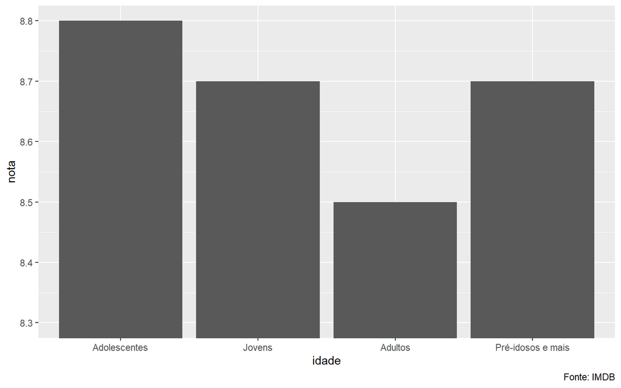

```r
fav_imdb_final |>
  ggplot()+
  aes(x = idade, y = nota)+
  geom_col()+
  coord_cartesian(ylim = c(8.3, 8.8))+
  scale_y_continuous(breaks = seq(8.3, 8.8, by = 0.1))+
  labs(caption = "Fonte: IMDB")
```

Como se percebe, a faixa etária que mais aprova o filme em questão é a relativa a adolescentes, ao passo que a nota média cai gradativamente conforme as demais faixas etárias. Isso pode ser explicado pelo fato de os mais jovens, que não assistem a tantos filmes, costumarem a procurar por filmes com nota alta no IMDB, como A Felicidade Não se Compra. Por fim, a nota média volta a crescer na faixa de pré-idosos e mais, o que pode ser explicado pelo fato de o filme, um clássido do cinema americano, evocar a nostalgia de seus espectadores mais velhos.

# Conclusão

Como visto acima, o IMDB é dono de uma ampla base de dados, de modo que é possível construir diversas transformações a partir daquilo que se encontra ali. Com o bom auxílio do R, linguagem de programação estatística, e seus mais diversos pacotes, formulados por seus próprios usuários, é possível que possamos responder de forma satisfatória muitas questões, sejam elas simples ou mais trincadas.